# UAV images with Agisoft PhotoScan

Jayan

2020-02-27

This tutorial will guide to create **3D point cloud**, **Digitla Elevation Model (DEM)**, and **Ortho-Mosaic** from your UAV-borne RGB images (*e.g. DJI FC330*). This tutorial use **Agisoft PhotoScan** software.

# Image export

- Copy camera images (JPGs) to the local folder in your computer from the micro SD card of the drone.
- Right click one of the image and click the properties and check the location data under the GPS section in the ‘Detail’ tab.

# Pre proceedure

- Open Agisoft PhotoScan.
- Click *Workflow* drop down menu and click *Add photos*. See Figure 1a.
- Browse to your folder and add all *JPG* files.
- *Workspace* shows loaded images as a list under *Chunk1* and *Cameras*. See the Figure 1b.
- The loaded photos can be seen on the *Photos* pane in the lower of the software GUI.
- In the *Model* pane, camera positions are shown with respective image names. Camera position can be turn on/off by clicking the *Camera* icon in the top tool bar.
- To view the images’ geotag data (including roataion angles), click *Reference* tab at lower left. See the Figure 1c.

[figure not shown]

Figure 1a: Workflow menu

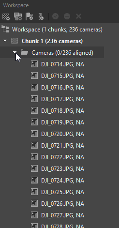

Figure 1b: Workspace view

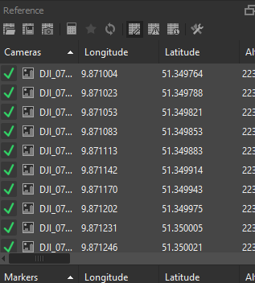

Figure 1c: Reference pane view